# Medidas de tendencia central

[Carlos Daniel Olivares Reyes](https://c4rlosdanielolivares.github.io)

Estadística 2022-2, [Facultad de economía](http://www.economia.unam.mx/)

2/3/2022

### 1. ¿Qué son las medidas de tendencia central? 🤔

> “La **medida de tendencia central** (moda,media y mediana), **parámetro de tendencia central** o **medida de centralización** es un número ubicado hacia el centro de la distribución de los valores de una serie de observaciones (medidas), en la que se encuentra ubicado el conjunto de los datos. Las medidas de tendencia central más utilizadas son: media, mediana u moda.

[Wikipedia (2022)](https://es.wikipedia.org/wiki/Medidas_de_tendencia_central)

Para este ejemplo, primero generaremos una serie de **100** números aleatorios entre **1** y **20** mediante la función `sample`. El argumento `TRUE` nos permitirá generar una muestra con remplazo:

```r
numeros <- sample(1:20, 100, TRUE)
numeros
```

```
##   [1]  9  6  7 16 11 15 17 14 18  6 11 20 12 20  3  4 15  7  2 10  1  4  2  8  8
##  [26] 10  3 14 15 17  6  7  4  8 16  6 20 11  5  4 13 11 14  2  8 15 17  7  1  7
##  [51]  6 11  6  9 16  1 14 14  6 11 13 19  8  8 15 20 11  5  7 14 17 13  8 19 11
##  [76] 18  2  5  2  3 12  3  1 11  1 14  3 11  9 20  1  5  8 16 11 19 16 19  8 13
```

### 2. Mediana 📍

> En el ámbito de la [estadística](https://es.wikipedia.org/wiki/Estad%C3%ADstica), la **mediana** (del latín *mediānus* ‘del medio’<sup>1</sup>) representa el valor de la variable de posición central en un conjunto de datos ordenados.

Wikipedia (2022)

Para obtener la **mediana**, podemos ordenar los `numeros` de menor a mayor, **el número que esté en medio de la muestra será la mediana**. Si utilizamos R, se puede hacer el cálculo de la **mediana** con la función `median`:

```r
mediana <- median(numeros)
mediana
```

```
## [1] 10
```

### 3. Media 🧮

> La media, también conocida como promedio, es el valor que se obtiene al dividir la suma de un conglomerado de números entre la cantidad de ellos.

[QuestionPro (2022)](https://www.questionpro.com/blog/es/la-media-la-mediana-y-la-moda/)

$$Media ={\frac {1}{n}}\sum _{i=1}^{n}a_{i}={\frac {a_{1}+a_{2}+\cdots +a_{n}}{n}}$$

Si usamos R, podemos obtener la media de una muestra si utlilizamos la función **mean**:

```r
media <- mean(numeros)
media
```

```
## [1] 10
```

### 4. Moda 📊

> La moda es el valor que aparece más dentro de un conglomerado. En un grupo puede haber dos modas y se conoce como bimodal, y más de dos modas o multimodal cuando se repiten más de dos valores; se llama amodal cuando en un conglomerado no se repiten los valores.

[QuestionPro (2022)](https://www.questionpro.com/blog/es/la-media-la-mediana-y-la-moda/)

Podemos saber cuál es la **frecuencia** (número de veces que aparece un elemento en una muestra) de cada número si dibujamos un **histograma** con la función `hist`, **aquel elemento con mayor frecuencia será la moda**:

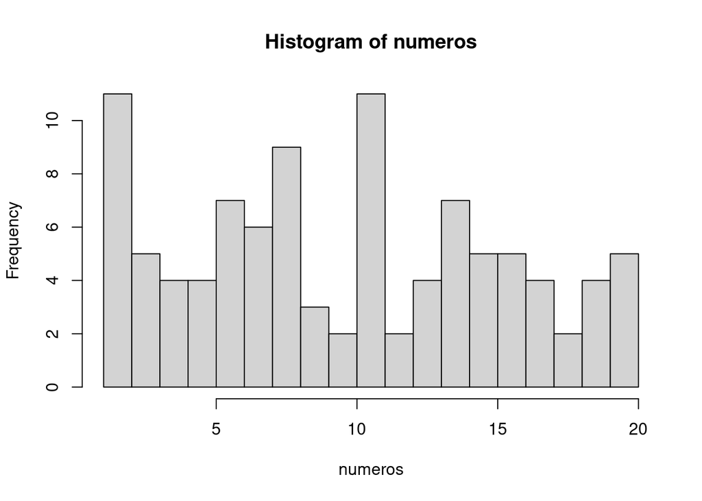

```r
# El argumento breaks nos permite dividir en histograma en las partes que queramos
hist(numeros, breaks = 20)
```

Para obtener un resultado con más precisión, podemos obtener la **moda** si generamos una **tabla de frecuencias** con la función `table` y la función `data.frame`, **aquel elemento con mayor frecuencia será la moda**:

```r
tabla.frecuencias <- data.frame(table(numeros))
tabla.frecuencias
```

```
##    numeros Freq
## 1        1    6
## 2        2    5
## 3        3    5
## 4        4    4
## 5        5    4
## 6        6    7
## 7        7    6
## 8        8    9
## 9        9    3
## 10      10    2
## 11      11   11
## 12      12    2
## 13      13    4
## 14      14    7
## 15      15    5
## 16      16    5
## 17      17    4
## 18      18    2
## 19      19    4
## 20      20    5
```

### 5. Ejercicio 👩‍💻👨‍💻✍

Aplica lo que aprendiste, obten la **mediana**, **media** y **moda** de la siguiente muestra de números:

```r
# Con la función seq, creamos una secuencia de 1 a 10 en intervalos de 0.1 en 0.1
secuencia <- seq(1, 10, 0.1)
muestra <- sample(secuencia, 100, TRUE)
muestra
```

```
##   [1] 5.9 1.8 2.1 6.5 1.8 4.0 3.8 8.7 8.1 1.9 2.8 3.7 9.4 2.9 9.5 1.8 8.5 7.7
##  [19] 6.3 1.9 5.2 2.6 4.2 4.8 9.5 5.8 2.8 5.9 6.0 4.4 8.2 7.6 5.1 4.2 8.9 6.2
##  [37] 1.3 7.5 6.9 6.3 6.1 2.8 3.8 1.7 4.7 8.6 2.2 7.1 7.1 5.3 2.0 8.0 2.1 4.2
##  [55] 8.9 7.4 4.9 6.2 5.4 7.2 3.6 8.0 8.7 6.1 9.3 2.4 6.2 5.0 7.7 3.3 5.0 3.5
##  [73] 4.9 2.9 5.2 3.9 4.5 7.9 1.5 7.1 3.1 1.3 6.3 7.9 8.1 6.0 3.7 7.9 9.6 1.9
##  [91] 3.7 4.6 2.9 3.4 6.6 4.6 9.7 8.7 1.1 1.6
```

##### Mediana

```r
# Aquí el cálculo de la mediana
mediana.muestra <- median(muestra)
mediana.muestra
```

```
## [1] 5.15
```

##### Media

```r
# Aquí el cálculo de la media
media.muestra <- mean(muestra)
media.muestra
```

```
## [1] 5.276
```

##### Moda

```r
# Aquí el cálculo de la moda
tabla.moda <- data.frame(table(muestra))
tabla.moda
```

```
##    muestra Freq
## 1      1.1    1
## 2      1.3    2
## 3      1.5    1
## 4      1.6    1
## 5      1.7    1
## 6      1.8    3
## 7      1.9    3
## 8        2    1
## 9      2.1    2
## 10     2.2    1
## 11     2.4    1
## 12     2.6    1
## 13     2.8    3
## 14     2.9    3
```

[output cut: 49 more lines]

💻[Código disponible en RStudio Cloud](https://rstudio.cloud/project/3671022)💻